# RFPM

Brian Church and Claire Detering

`RFPM` provides an implementation of the Floating Percentile Model (FPM) in the R statistical environment. The FPM was originally developed by others on behalf of the Washington State Department of Ecology (Avocet 2003) and has since been recommended for use in Washington, Oregon, and Idaho (Ecology 2011). The FPM currently exists as a Microsoft Excel macro (written with Visual Basic for Applications). `RFPM` represents an independent effort to port the FPM to R with the purpose of:  
- correcting a data handling error  
- streamlining the chemical selection and sediment quality benchmark calculation procedures  
- providing new tools to rapidly evaluate and refine benchmarks  
- improving several aspects of the FPM algorithm  
- improving the availability, accessibility, and transparency of the FPM tool

The purpose of this vignette is to lead the reader through an example analysis of real-world data using the core functions of `RFPM` rather than go into great detail on any particular function. For more function details, see the help files by using `?` or `help()` (or by navigating in RStudio to the Packages tab, selecting RFPM from the list of available packages, and then selecting the function of interest).

## Functionality

The main user interface within `RFPM` is via the `FPM` function. To use this function, the user must first prepare a sediment chemistry and toxicity data.frame that contains one or more chemical columns and a single toxicity column called `Hit`. Several example datasets are provided with `RFPM` with this structure, for example `h.northport`, which we will evaluate repeatedly in this vignette. Other datasets include the empirical `c.northport` and `h.tristate` as well as simulated FPM data `perfect`, `lowNoise`, and `highNoise`.

Other key functions that the user is directed to include `optimFPM`, `cvFPM`, and `chemVI` which can help the user to explore and refine FPM inputs and optimize FPM outputs.

## Case study - Amphipod toxicity in Northport, WA sediments

In this vignette, we focus on evaluating a case study dataset called `h.northport`, which includes a data.frame of bulk sediment chemistry metals concentrations (mg/kg) and `Hit` data. Hits are logical results indicating whether a particular sample was deemed toxic (`TRUE`) or not (`FALSE`) based on the *Hyalella azteca* biomass endpoint in 28-day laboratory exposures. The definition of a toxic Hit is up to the practitioner and not a part of the model. Data must be input to `FPM` in a cross-tab (wide) format, meaning each sediment chemical has a unique column and each sample has just one row.

```r
head(h.northport)
```

```
#>        Al    As     Cu    Cd    Cr     Fe    Pb    Hg    Ni    Zn Organism
#> 442  8640  8.38  396.0 3.740  34.6  56900 226.0 0.159 13.20  4300       HA
#> 443  5890  7.69  167.0 4.860  18.7  28500 219.0 0.247 14.00  1780       HA
#> 444 10200 11.10  913.0 0.727  50.8  83300 151.0 0.051  9.91  6490       HA
#> 445 15800 14.60 1630.0 0.688 100.0 161000 211.0 0.016 13.10 13600       HA
#> 446  5950  2.55   30.4 0.721  11.5  14600  63.8 0.020 11.20   484       HA
#> 447  8370  8.74  644.0 0.774  39.3  62400  99.2 0.027  9.68  4740       HA
#>     Meas_Day Endpoint   Hit
#> 442       28  Biomass FALSE
#> 443       28  Biomass FALSE
#> 444       28  Biomass  TRUE
#> 445       28  Biomass  TRUE
#> 446       28  Biomass FALSE
#> 447       28  Biomass FALSE
```

To run `FPM`, you will need to specify, at a minimum, the data.frame object and the column names associated with sediment chemistry data. As noted above, `FPM` also requires that the data.frame include a column called `Hit`. Columns other than `Hit` and those specified using the `paramList` argument are ignored.

```r
p.northport <- names(h.northport)[1:10] ## all chemical column names
FPM(data = h.northport, paramList = p.northport) ## minimum input - dataset and chemical column names
```

```
#> $FPM
#>     Cr   Cu    Fe  Zn FN_crit TP FN TN FP   pFN   pFP  sens  spec    OR    FM
#> 1 26.7 2740 27400 738     0.2 49 12 35 51 0.197 0.593 0.803 0.407 0.571 0.627
#>     MCC
#> 1 0.222
```

The output of `FPM` is a list with at least 1 item called `FPM`, which displays three types of data:  
- The sediment quality benchmark for each of the chemicals selected by `FPM` as significant (meaning that concentrations when `Hit == TRUE` are significantly greater than when `Hit == FALSE`).  
- Selected `FN_crit` value, the user-defined limit on benchmark conservatism (default = `0.2`)  
- Classification metrics: e.g., false negatives rate (`pFN`), false positive rate (`pFP`), sensitivity (`sens`), specificity (`spec`), overall reliability (`OR`), Fowlkes-Mallows Index (`FM`), and Matthew’s Correlation Coefficient (`MCC`). These provide an indication of the relative fit of the FPM benchmarks to the underlying toxicity dataset.

This is technically all that was required to run the FPM on this example dataset. There is of course a lot going on behind the scenes. Functions that were used within FPM include:  
- `chemSig`: chemical selection algorithm, which evaluates distribution assumptions of normality and equal variance, then applies appropriate hypothesis test methods to identify significant differences between concentrations when `Hit == TRUE` and `Hit == FALSE`. The output of `chemSig` is a logical vector indicating which chemicals are significant (therefore selected by `FPM` for generating benchmarks).  
- `chemSigSelect`: a function that uses `chemSig` but instead returns the chemistry data for significant chemicals and has options for plotting chemistry data distributions to compare `Hit == TRUE` and `Hit == FALSE` subsets. Setting `plot = TRUE` in `FPM` turns on plot outputs (by passing that argument to `chemSigSelect`).

As an example, see the following figures generated by `plot.chemSigSelect` (identical to those generated by `FPM` when `plot = TRUE`) for a significant chemical (`Cr`), shown with blue points, and a non-significant chemical (`Al`), shown with green points:

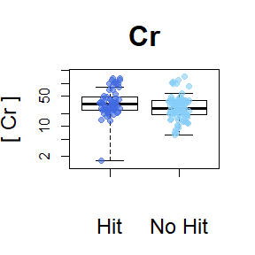

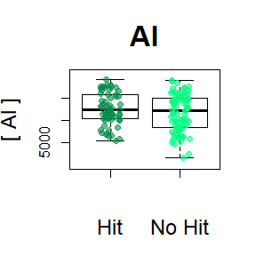

```r
plot(chemSigSelect(h.northport[, c("Al", "Cr", "Hit")], paramList = c("Al", "Cr")), type = "boxplot")
```

There are also many arguments that can be adjusted in `FPM` that affect how `chemSig` and `chemSigSelect` function or how the FPM algorithm itself functions. Users can adjust the test methods/assumptions for selecting chemicals, force the FPM to accept the assumptions of the original Excel-based function (i.e., `ExcelMode == TRUE`), etc. As noted above, the output of `FPM` is a list; additional items can be appended to the list if the user sets the `densInfo`, `lockInfo`, or `hitInfo` arguments equal to `TRUE`. Respectively, these provide information about 1) how much each of the benchmarks varied within the FPM algorithm, 2) what caused each benchmark to lock into place and in what order, and 3) what the predicted `Hit` values would be based on the calculated benchmarks. We have been interested in each of these components at various times of model development, but expect the typical user to not need this information.

See `?FPM` and `?chemSig` for more information.